# ISYE 6501

Homework 1

Artur Cabral, Marta Bras, Pedro Pinto, Katie Price

2019-08-27

# Question 2.1

*Describe a situation or problem from your job, everyday life, current events, etc., for which a classification model would be appropriate. List some (up to 5) predictors that you might use.*

An example of a situation is deciding if a student is accepted or not in the MSA program.

The class in this case would be 0 - not accepted or 1 - accepted.

The classifiers could be for example:

1. Statistics/probability background (1-yes, 0 - no)
2. Coding background (1-yes, 0 - no)
3. GPA
4. GRE score
5. Number of years of work experience

# Question 2.2

*2.2.1 Using the support vector machine function ksvm contained in the R package kernlab, find a good classifier for this data. Show the equation of your classifier, and how well it classifies the data points in the full data set. (Don’t worry about test/validation data yet; we’ll cover that topic soon.)*

### 1. Importing and preparing the data

```r
credit_card <- read.table("credit_card_data-headers.txt", sep= "", header = TRUE)
credit_card <- data.matrix(credit_card)
credit_card[,11]  <- as.factor(credit_card[,11])
class <- credit_card[,11]
classifiers <-  credit_card[,1:10]
```

### 2. Looping through multiple values of C to find the one that minimizes training error

The C parameters balances the trade-off between having a large margin and separating the positive and unlabeled on the training set. It is important to choose a C parameter that that allows for good generalization. Instead of testing manually, we can do it in a loop.

```r
cValues <- c(0.00001, 0.001, 0.01, 0.1, 10, 20, 30, 40, 50, 80, 100, 1000, 1000000)

for(i in cValues){
  model <-  ksvm(classifiers, class, kernel="vanilladot", type = "C-svc", C=i, scaled=TRUE)
  pred <- predict(model,classifiers)
  confusionMatrix <- confusionMatrix(as.factor(pred), as.factor(class))
  accuracy <- confusionMatrix$overall["Accuracy"]*100
  cat("\nAccuracy: ", accuracy, "%")
}
```

[output not shown]

We need to find another way to chose the best C value. To do so, we can use the tune() function from e1071 to test various C values.

The tune function performes a grid search using a 10 fold cross validation to select the best C value to maximize accuracy in the testing datasets.

### 3. Using the tune function to chose the optimal C

```r
#creating dataframe
credit_card_2 <- data.frame(classifiers =classifiers, class)

# find optimal cost of misclassification
svmfit <- svm(class~., data = credit_card_2, kernel = "linear", cost = 10, gamma = 1)

tune.out <- tune(svm, class~., data = credit_card_2, kernel = "linear",
                 ranges = list(cost = c(0.001, 100,0.01, 0.1, 1, 5, 10, 100)))

plot(svmfit, credit_card_2)

# extract the best model
(bestmod <- tune.out$best.model)
```

```
##
## Call:
## best.tune(method = svm, train.x = class ~ ., data = credit_card_2,
##     ranges = list(cost = c(0.001, 100, 0.01, 0.1, 1, 5, 10, 100)),
##     kernel = "linear")
##
##
## Parameters:
##    SVM-Type:  eps-regression
##  SVM-Kernel:  linear
##        cost:  0.01
##       gamma:  0.1
##     epsilon:  0.1
##
##
## Number of Support Vectors:  289
```

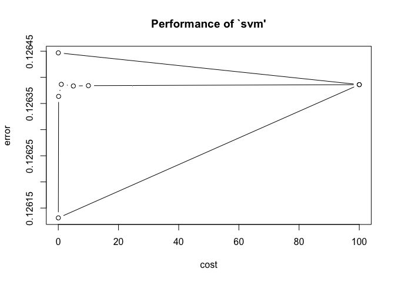

```r
plot(tune.out)
```

From the dataset, the optimal C is 0.01. We can now build the ksvm model usimg this value for C.

### 4. KSVM model and results

Using the 0.01 value for C from tune function, we get that the best model is:

```r
best_model <- ksvm(classifiers, class, kernel="vanilladot", type = "C-svc", C=0.01,scaled=TRUE)
best_model
```

```
## Support Vector Machine object of class "ksvm"
##
## SV type: C-svc  (classification)
##  parameter : cost C = 0.01
##
## Linear (vanilla) kernel function.
##
## Number of Support Vectors : 288
##
## Objective Function Value : -2.2926
## Training error : 0.136086
```

```r
ypred <- predict(best_model, classifiers)
misclass <- table(predict = ypred, truth = class)

misclass
```

```
##        truth
## predict   1   2
##       1 286  17
##       2  72 279
```

### 5. Decision boundary function

```r
# calculate a1…am
a <- colSums(best_model@xmatrix[[1]] * best_model@coef[[1]])
a
```

```
##            A1            A2            A3            A8            A9
## -0.0001500738 -0.0014818294  0.0014083130  0.0072863886  0.9916470037
##           A10           A11           A12           A14           A15
## -0.0044661236  0.0071482899 -0.0005468386 -0.0016930578  0.1054824270
```

```r
# calculate a0
a0 <- best_model@b
a0
```

```
## [1] -0.08198854
```

The decision boundary function is:

*-0.08198854 + -0.0001500738A1 + -0.0014818294A2 + 0.0014083130A3 + 0.0072863886A8 + 0.9916470037A9 + -0.0044661236A10 + 0.0071482899A11 + -0.0005468386A2 + -0.0016930578A14 + 0.1054824270A15*

*2.2.2 You are welcome, but not required, to try other (nonlinear) kernels as well; we’re not covering them in this course, but they can sometimes be useful and might provide better predictions than vanilladot.*

We tried multiple kernel functions and the one below registered the highest accuracy:

```r
model <- ksvm(classifiers, class, kernel="splinedot", type = "C-svc", C=10,scaled=TRUE)
pred <- predict(model,classifiers)
confusionMatrix <- confusionMatrix(as.factor(pred), as.factor(class))
accuracy <- confusionMatrix$overall["Accuracy"]*100
accuracy
```

```
## Accuracy
## 97.85933
```

```r
# calculate a1…am
a <- colSums(model@xmatrix[[1]] * model@coef[[1]])
a
```

```
##          A1          A2          A3          A8          A9         A10
##   0.5867821  45.8370485 -10.2830639  -2.8255894  -1.3364910   6.3495279
##         A11         A12         A14         A15
##  -2.0972843  11.5009855 -25.5777082   1.1260771
```

```r
# calculate a0
a0 <- model@b
a0
```

```
## [1] -27.16875
```

Using the splinedot kernel we minimize the training set error.

*2.2.3 Using the k-nearest-neighbors classification function kknn contained in the R kknn package, suggest a good value of k, and show how well it classifies that data points in the full data set. Don’t forget to scale the data (scale=TRUE in kknn).*

```r
credit_card_df <- read.table("credit_card_data.txt", sep="",header = TRUE)
df2<-credit_card_df[complete.cases(credit_card_df),]
v_accuracy <- vector()
for (k in 1:30){
    pred <- c()
    for (i in 1:nrow(credit_card_df)){
        knn <- kknn(X1.4 ~ .,credit_card_df[-i,], credit_card_df[i, ], k = k, distance=2,kernel="rectangular",scale=TRUE)
        pred <- c(pred, as.integer(fitted(knn)+0.5))
    }
    #pred <- pred-1
    accuracy <- sum(pred == credit_card_df[,11]) / nrow(credit_card_df)
    cat("\n For K = ", k, "accuracy = ", accuracy, "\n")
    v_accuracy <- c(v_accuracy,accuracy)
}
```

```
##
##  For K =  1 accuracy =  0.8147014
##
##  For K =  2 accuracy =  0.8039816
##
##  For K =  3 accuracy =  0.8223583
##
##  For K =  4 accuracy =  0.8453292
##
##  For K =  5 accuracy =  0.8453292
##
##  For K =  6 accuracy =  0.8514548
##
##  For K =  7 accuracy =  0.8453292
##
##  For K =  8 accuracy =  0.8407351
##
##  For K =  9 accuracy =  0.8315467
##
##  For K =  10 accuracy =  0.8361409
##
##  For K =  11 accuracy =  0.8346095
##
##  For K =  12 accuracy =  0.8269525
##
##  For K =  13 accuracy =  0.8300153
##
##  For K =  14 accuracy =  0.8269525
##
##  For K =  15 accuracy =  0.8238897
##
##  For K =  16 accuracy =  0.8254211
##
##  For K =  17 accuracy =  0.8223583
##
##  For K =  18 accuracy =  0.8300153
##
##  For K =  19 accuracy =  0.8223583
##
##  For K =  20 accuracy =  0.8330781
##
##  For K =  21 accuracy =  0.8392037
##
##  For K =  22 accuracy =  0.8315467
##
##  For K =  23 accuracy =  0.8422665
##
##  For K =  24 accuracy =  0.8392037
##
##  For K =  25 accuracy =  0.8330781
##
##  For K =  26 accuracy =  0.8300153
##
##  For K =  27 accuracy =  0.8361409
##
##  For K =  28 accuracy =  0.8330781
##
##  For K =  29 accuracy =  0.8392037
##
##  For K =  30 accuracy =  0.8330781
```

```r
#v_accuracy
cat("\n The best value of k is K = ", match(c(max(v_accuracy,na.rm = TRUE)),v_accuracy), " with accuracy = ", max(v_accuracy,na.rm = TRUE), "\n")
```

```
##
##  The best value of k is K =  6  with accuracy =  0.8514548
```

The accuracy is higher using a SVM model than using the k-nearest-neighbors model.